# Manjeet Singh - Data Science Challenge Lalamove

The Challenge: - Build a model that predicts if a new placed and responded order would be completed or not and at what completion probability.

Contents

1) Data Cleaning

2) Feature engineering

3) Data Visulaistion

4) Modelling- I

5) Sampling

6) Modelling -II

Lets Import the necessay libraries

```python
import pandas as pd
from matplotlib import pyplot as plt
from datetime import datetime
import statistics
import numpy as np
import seaborn as sns
```

Import the data

```python
df = pd.read_csv('C:/Users/msingh/Desktop/lalamove/orders1.csv')
columns = df.columns.values.tolist()
print(columns)
```

```
['Available Drivers', 'Cancel Time', 'Order ID', 'Placed Time', 'Reject Time', 'Response Distance', 'Response Time', 'Service Type']
```

We have many dates/times in the data and very less number of features. So,we need to create some features to built our model. Firstly, we have to create a target variable from the given data.

There are 2 scenarios -

Either Drive rejected the Order or Customer rejected the order- In any of the case it means order was not comlpeted. And if none of them rejected then it means order was completed.

I will create a target variable - Stage, on the basis of these two scenarios.

# 1 Data Cleaning

```python
#Lets check the missing values
percent_missing = df.isnull().sum() * 100 / len(df)
percent_missing
```

```
Available Drivers     0.000000
Cancel Time          88.179612
Order ID              0.000000
Placed Time           0.000000
Reject Time          96.152913
Response Distance     5.594660
Response Time         4.235437
Service Type          0.000000
dtype: float64
```

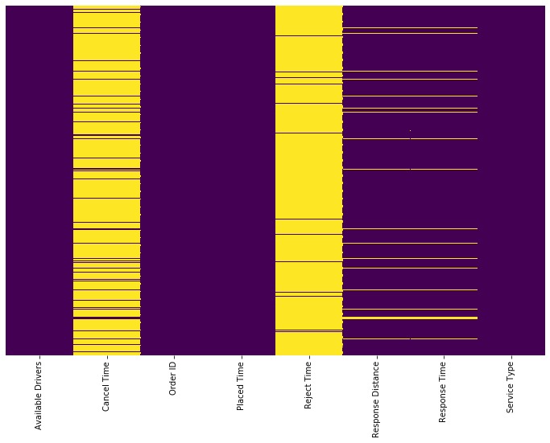

```python
fig, (axis1) = plt.subplots(1,1,figsize=(12,8))
sns.heatmap(df.isnull(),yticklabels=False,cbar=False,cmap='viridis')
```

So we can see there is alot of missing values in Cancel time(88%) and Reject Time(96%).

Both of these columns are the values when either a driver or a customer rejected the order.

So it means whenever both of these columns have missing values together, it means no-one cancelled or rejected the order and our order was completed.

# Lets use this to create a target column- "Stage" as I mentioned above.

# 2 FEATURE Engineering

First I will fix the missing values of other two columns- Response Distance and Response Time and Then I will proceed to Creating our target variable.

I will handle missing values in response Distance column by imputing mean in and by dropping all the missing rows in Response Time column.

```python
mean_value=df['Response Distance'].mean()
df['Response Distance']=df['Response Distance'].fillna(mean_value)
#df['Response Time'] = df['Response Time'].replace(0, np.NaN)
#df['Response Time'].dropna(inplace=True)
df = df.dropna(subset=['Response Time'])
print(df.shape)
```

```
(15782, 8)
```

Create a new coulmn - Stage. It will be our target variable.

```python
df = df.where(pd.notnull(df),'None')
def f(x):
  if x['Cancel Time'] == 'None' and x['Reject Time'] == 'None':
    return 1
  else:
    return 0
df['Stage'] = df.apply(f, axis=1)
df
```

|  | Available Drivers | Cancel Time | Order ID | Placed Time | Reject Time | Response Distance | Response Time | Service Type | Stage |
| --- | --- | --- | --- | --- | --- | --- | --- | --- | --- |
| 0 | 39 | None | 1 | 6/8/2018 8:01:22 AM | None | 4615.0 | 6/8/2018 8:01:46 AM | Van | 1 |
| 1 | 68 | None | 2 | 6/8/2018 8:01:23 AM | None | 4785.0 | 6/8/2018 8:01:56 AM | Van | 1 |
| 2 | 10 | None | 3 | 6/8/2018 8:06:39 AM | None | 15964.0 | 6/8/2018 8:07:05 AM | Van | 1 |
| 3 | 76 | None | 4 | 6/8/2018 8:14:00 AM | None | 2459.0 | 6/8/2018 8:14:09 AM | Van | 1 |
| 4 | 98 | None | 5 | 6/8/2018 8:16:00 AM | None | 5510.0 | 6/8/2018 8:16:21 AM | Van | 1 |
| ... | ... | ... | ... | ... | ... | ... | ... | ... | ... |
| 16475 | 214 | None | 16476 | 7/6/2018 7:46:47 AM | None | 1626.0 | 7/6/2018 7:47:00 AM | Van | 1 |
| 16476 | 118 | None | 16477 | 7/6/2018 7:50:27 AM | None | 3016.0 | 7/6/2018 7:50:41 AM | Van | 1 |
| 16477 | 187 | None | 16478 | 7/6/2018 7:52:16 AM | None | 4189.0 | 7/6/2018 7:52:54 AM | Van | 1 |
| 16478 | 122 | None | 16479 | 7/6/2018 7:57:48 AM | None | 2602.0 | 7/6/2018 7:58:00 AM | Van | 1 |
| 16479 | 39 | None | 16480 | 7/6/2018 7:58:15 AM | None | 7335.0 | 7/6/2018 7:59:23 AM | Motorcycle | 1 |

15782 rows × 9 columns

This column have binary values- 1 0r 0.

1 means order was completed and 0 means order was not completed(either cancelled or rejected)

Lets see the distribution of this column

```python
df['Stage'].value_counts(normalize=True)
```

```
1    0.880623
0    0.119377
Name: Stage, dtype: float64
```

Its 88% to 12%, So our target variable is highly imbalanced. We will deal with this in later stage.

We have already created a column based on "Cancel Time" and "Reject Time" columns . Now, I will just drop these two columns. Way too many missing values in these two columns.

```python
columns = ['Cancel Time','Reject Time']
df.drop(columns, inplace=True, axis=1)
```

Now, Lets deal with other date columns in our datset. I will use columns -"Placed Time" and "Response Time" to create some features for our model.

First lets just Rename them

```python
df.rename(columns={'Placed Time':'PlacedDate'}, inplace=True)
df.rename(columns={'Response Time':'ResponseDate'}, inplace=True)
```

# Split Date and Time. It will give us two new columns - Placed Time and Response Time

```python
df['PlacedDate'] = pd.to_datetime(df['PlacedDate'])
df['PlacedTime'],df['PlacedDate']= df['PlacedDate'].apply(lambda x:x.time()), df['PlacedDate'].apply(lambda x:x.date())
df['ResponseDate'] = pd.to_datetime(df['ResponseDate'])
df['ResponseTime'],df['ResponseDate']= df['ResponseDate'].apply(lambda x:x.time()), df['ResponseDate'].apply(lambda x:x.date())
df
```

|  | Available Drivers | Order ID | PlacedDate | Response Distance | ResponseDate | Service Type | Stage | PlacedTime | ResponseTime |
| --- | --- | --- | --- | --- | --- | --- | --- | --- | --- |
| 0 | 39 | 1 | 2018-06-08 | 4615.0 | 2018-06-08 | Van | 1 | 08:01:22 | 08:01:46 |
| 1 | 68 | 2 | 2018-06-08 | 4785.0 | 2018-06-08 | Van | 1 | 08:01:23 | 08:01:56 |
| 2 | 10 | 3 | 2018-06-08 | 15964.0 | 2018-06-08 | Van | 1 | 08:06:39 | 08:07:05 |
| 3 | 76 | 4 | 2018-06-08 | 2459.0 | 2018-06-08 | Van | 1 | 08:14:00 | 08:14:09 |
| 4 | 98 | 5 | 2018-06-08 | 5510.0 | 2018-06-08 | Van | 1 | 08:16:00 | 08:16:21 |
| ... | ... | ... | ... | ... | ... | ... | ... | ... | ... |
| 16475 | 214 | 16476 | 2018-07-06 | 1626.0 | 2018-07-06 | Van | 1 | 07:46:47 | 07:47:00 |
| 16476 | 118 | 16477 | 2018-07-06 | 3016.0 | 2018-07-06 | Van | 1 | 07:50:27 | 07:50:41 |
| 16477 | 187 | 16478 | 2018-07-06 | 4189.0 | 2018-07-06 | Van | 1 | 07:52:16 | 07:52:54 |
| 16478 | 122 | 16479 | 2018-07-06 | 2602.0 | 2018-07-06 | Van | 1 | 07:57:48 | 07:58:00 |
| 16479 | 39 | 16480 | 2018-07-06 | 7335.0 | 2018-07-06 | Motorcycle | 1 | 07:58:15 | 07:59:23 |

15782 rows × 9 columns

```python
df['PlacedDate'] = pd.to_datetime(df['PlacedDate'], errors='coerce')
df['PlacedDate'] = pd.to_datetime(df['PlacedDate'], format="%d-%m-%y")
```

# Now, We will create two seperate features. Placed Day , Placed Month from PlacedDate Column

```python
df['Placedday'] = df['PlacedDate'].dt.dayofweek
df['PlacedMonth'] = df['PlacedDate'].dt.month
```

I coluld have created same kind of two columns for Response Date as well but it wont make any sense as Day/Month would be same in both the cases.

```python
df
```

|  | Available Drivers | Order ID | PlacedDate | Response Distance | ResponseDate | Service Type | Stage | PlacedTime | ResponseTime | Placedday | PlacedMonth |
| --- | --- | --- | --- | --- | --- | --- | --- | --- | --- | --- | --- |
| 0 | 39 | 1 | 2018-06-08 | 4615.0 | 2018-06-08 | Van | 1 | 08:01:22 | 08:01:46 | 4 | 6 |
| 1 | 68 | 2 | 2018-06-08 | 4785.0 | 2018-06-08 | Van | 1 | 08:01:23 | 08:01:56 | 4 | 6 |
| 2 | 10 | 3 | 2018-06-08 | 15964.0 | 2018-06-08 | Van | 1 | 08:06:39 | 08:07:05 | 4 | 6 |
| 3 | 76 | 4 | 2018-06-08 | 2459.0 | 2018-06-08 | Van | 1 | 08:14:00 | 08:14:09 | 4 | 6 |
| 4 | 98 | 5 | 2018-06-08 | 5510.0 | 2018-06-08 | Van | 1 | 08:16:00 | 08:16:21 | 4 | 6 |
| ... | ... | ... | ... | ... | ... | ... | ... | ... | ... | ... | ... |
| 16475 | 214 | 16476 | 2018-07-06 | 1626.0 | 2018-07-06 | Van | 1 | 07:46:47 | 07:47:00 | 4 | 7 |
| 16476 | 118 | 16477 | 2018-07-06 | 3016.0 | 2018-07-06 | Van | 1 | 07:50:27 | 07:50:41 | 4 | 7 |
| 16477 | 187 | 16478 | 2018-07-06 | 4189.0 | 2018-07-06 | Van | 1 | 07:52:16 | 07:52:54 | 4 | 7 |
| 16478 | 122 | 16479 | 2018-07-06 | 2602.0 | 2018-07-06 | Van | 1 | 07:57:48 | 07:58:00 | 4 | 7 |
| 16479 | 39 | 16480 | 2018-07-06 | 7335.0 | 2018-07-06 | Motorcycle | 1 | 07:58:15 | 07:59:23 | 4 | 7 |

15782 rows × 11 columns

# Lets Create another features as Placedhour and RespondHour from placed time and Response Time respectivly.

```python
df['Placedhour'] = pd.to_datetime(df['PlacedTime'], format='%H:%M:%S').dt.hour
df['Respondhour'] = pd.to_datetime(df['ResponseTime'], format='%H:%M:%S').dt.hour
```

# 3 Data Visualisation

Lets analyse some features against Stage column

```python
pd.crosstab(df['Stage'], df['Placedday'], margins=True)
```

| Placedday Stage | 0 | 1 | 2 | 3 | 4 | 5 | 6 | All |
| --- | --- | --- | --- | --- | --- | --- | --- | --- |
| 0 | 345 | 274 | 269 | 312 | 202 | 274 | 208 | 1884 |
| 1 | 2415 | 2272 | 2498 | 2386 | 1134 | 2101 | 1092 | 13898 |
| All | 2760 | 2546 | 2767 | 2698 | 1336 | 2375 | 1300 | 15782 |

Day wise total number of orders

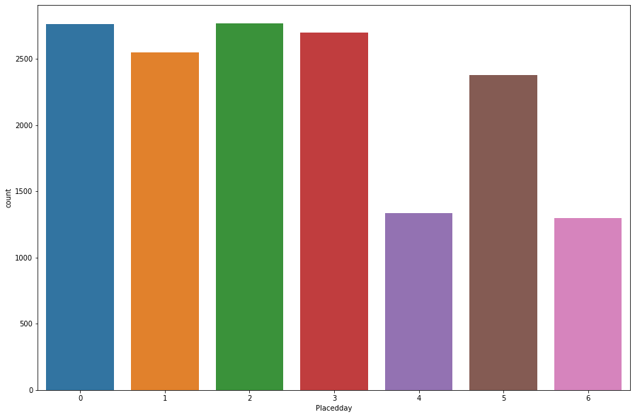

```python
fig, (axis1) = plt.subplots(1,1,figsize=(15,10))
sns.countplot(x='Placedday', data=df);
```

Day wise completed orders and cancelled orders

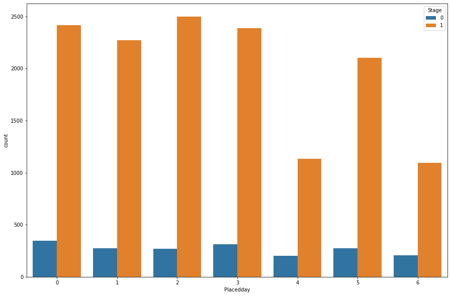

```python
fig, (axis1) = plt.subplots(1,1,figsize=(15,10))
sns.countplot(df['Placedday'], hue=df['Stage'])
```

Service type distribution of orders for each day of the week

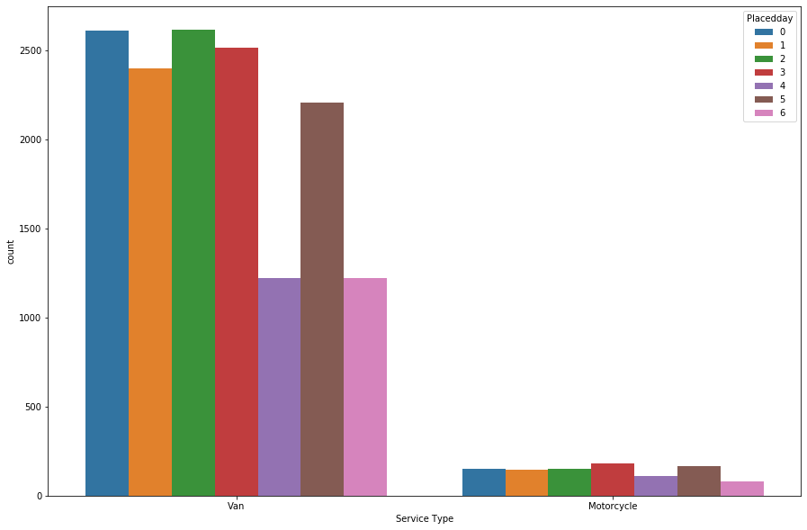

```python
fig, (axis1) = plt.subplots(1,1,figsize=(15,10))
sns.countplot(df['Service Type'], hue=df['Placedday'])
```

Service type distribution of our orders on Hourly Basis.

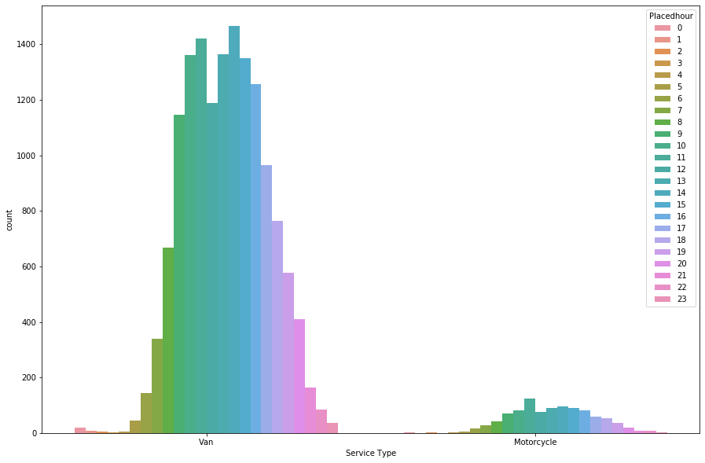

```python
fig, (axis1) = plt.subplots(1,1,figsize=(15,10))
sns.countplot(df['Service Type'], hue=df['Placedhour'])
```

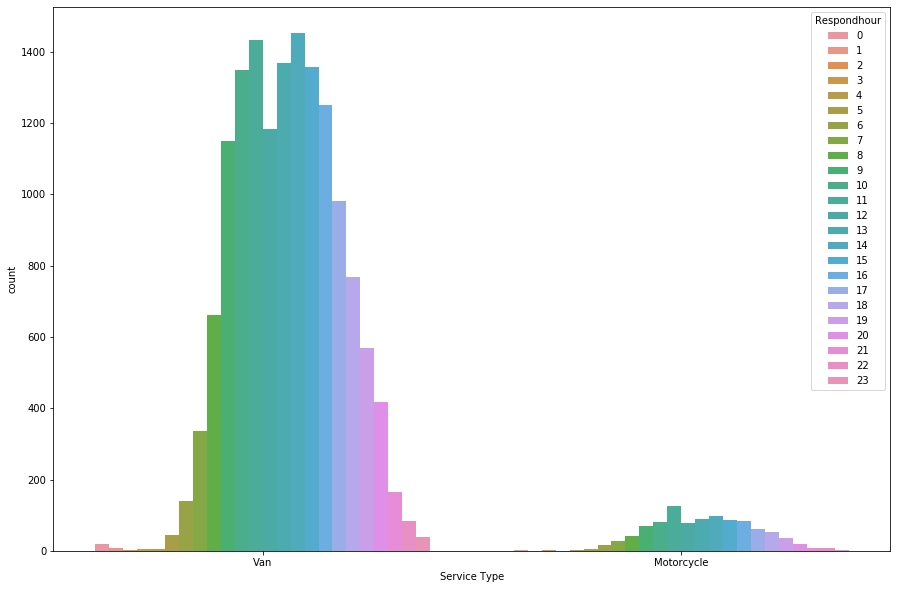

```python
fig, (axis1) = plt.subplots(1,1,figsize=(15,10))
sns.countplot(df['Service Type'], hue=df['Respondhour'])
```

Stage vs Service Type

```python
pd.crosstab(df['Stage'], df['Service Type'], margins=True)
```

| Service Type Stage | Motorcycle | Van | All |
| --- | --- | --- | --- |
| 0 | 220 | 1664 | 1884 |
| 1 | 770 | 13128 | 13898 |
| All | 990 | 14792 | 15782 |

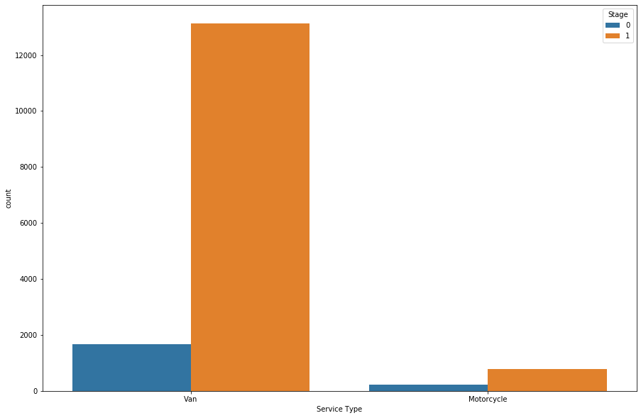

```python
fig, (axis1) = plt.subplots(1,1,figsize=(15,10))
sns.countplot(df['Service Type'], hue=df['Stage'])
```

Stage vs Placed Month

```python
pd.crosstab(df['Stage'], df['PlacedMonth'], margins=True)
```

| PlacedMonth Stage | 6 | 7 | All |
| --- | --- | --- | --- |
| 0 | 1415 | 469 | 1884 |
| 1 | 10219 | 3679 | 13898 |
| All | 11634 | 4148 | 15782 |

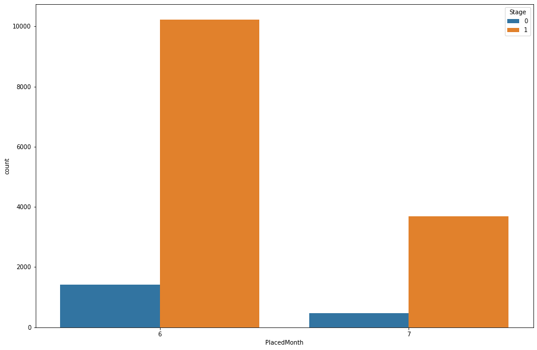

```python
fig, (axis1) = plt.subplots(1,1,figsize=(15,10))
sns.countplot(df['PlacedMonth'], hue=df['Stage'])
```

Stage vs Placed hour

```python
pd.crosstab(df['Stage'], df['Placedhour'], margins=True)
```

| Placedhour Stage | 0 | 1 | 2 | 3 | 4 | 5 | 6 | 7 | 8 | 9 | ... | 15 | 16 | 17 | 18 | 19 | 20 | 21 | 22 | 23 | All |
| --- | --- | --- | --- | --- | --- | --- | --- | --- | --- | --- | --- | --- | --- | --- | --- | --- | --- | --- | --- | --- | --- |
| 0 | 11 | 5 | 2 | 1 | 1 | 10 | 35 | 63 | 81 | 128 | ... | 164 | 177 | 130 | 106 | 95 | 73 | 44 | 20 | 16 | 1884 |
| 1 | 9 | 3 | 3 | 2 | 6 | 40 | 124 | 303 | 631 | 1088 | ... | 1274 | 1162 | 895 | 710 | 516 | 356 | 128 | 73 | 22 | 13898 |
| All | 20 | 8 | 5 | 3 | 7 | 50 | 159 | 366 | 712 | 1216 | ... | 1438 | 1339 | 1025 | 816 | 611 | 429 | 172 | 93 | 38 | 15782 |

3 rows × 25 columns

```python
pd.crosstab(df['Stage'], df['Respondhour'], margins=True)
```

| Respondhour Stage | 0 | 1 | 2 | 3 | 4 | 5 | 6 | 7 | 8 | 9 | ... | 15 | 16 | 17 | 18 | 19 | 20 | 21 | 22 | 23 | All |
| --- | --- | --- | --- | --- | --- | --- | --- | --- | --- | --- | --- | --- | --- | --- | --- | --- | --- | --- | --- | --- | --- |
| 0 | 11 | 5 | 1 | 2 | 1 | 10 | 34 | 62 | 81 | 129 | ... | 166 | 178 | 132 | 106 | 88 | 80 | 43 | 21 | 17 | 1884 |
| 1 | 9 | 3 | 3 | 2 | 6 | 39 | 122 | 300 | 622 | 1093 | ... | 1277 | 1157 | 910 | 715 | 516 | 357 | 131 | 72 | 23 | 13898 |
| All | 20 | 8 | 4 | 4 | 7 | 49 | 156 | 362 | 703 | 1222 | ... | 1443 | 1335 | 1042 | 821 | 604 | 437 | 174 | 93 | 40 | 15782 |

3 rows × 25 columns

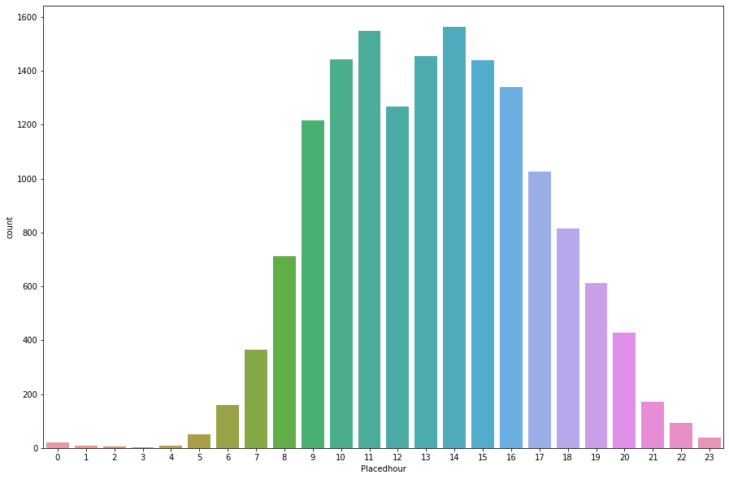

```python
import seaborn as sns
fig, (axis1) = plt.subplots(1,1,figsize=(15,10))
sns.countplot(x='Placedhour', data=df);
```

We are busiest from 9 AM to 6 PM. Looks like more than 80% of our orders comes into this time frame.

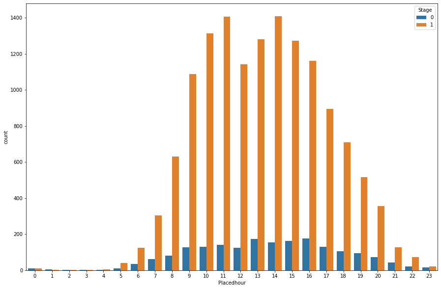

```python
fig, (axis1) = plt.subplots(1,1,figsize=(15,10))
sns.countplot(df['Placedhour'], hue=df['Stage'])
```

Now we will start our process for modelling. For that we need to fix service Type column.

# 4 Modelling

One hot encoding to create dummy variable.

```python
dummy_variables = ['Service Type']
for var in dummy_variables:
    dummy = pd.get_dummies(df[var], prefix = var, drop_first = False)
    df = pd.concat([df, dummy], axis = 1)
df = df.drop(dummy_variables, axis = 1)
```

```python
columns = df.columns.values.tolist()
print(columns)
```

```
['Available Drivers', 'Order ID', 'PlacedDate', 'Response Distance', 'ResponseDate', 'Stage', 'PlacedTime', 'ResponseTime', 'Placedday', 'PlacedMonth', 'Placedhour', 'Respondhour', 'Service Type_Motorcycle', 'Service Type_Van']
```

```python
print("------  Data Types  ----- \n",df.dtypes)
```

```
------  Data Types  -----
 Available Drivers                   int64
Order ID                            int64
PlacedDate                 datetime64[ns]
Response Distance                 float64
ResponseDate                       object
Stage                               int64
PlacedTime                         object
ResponseTime                       object
Placedday                           int64
PlacedMonth                         int64
Placedhour                          int64
Respondhour                         int64
Service Type_Motorcycle             uint8
Service Type_Van                    uint8
dtype: object
```

We have used some columns to create features, So i will just drop those columns which I cant use in the model

```python
df = df.drop(['Order ID','PlacedDate','ResponseDate','PlacedTime','ResponseTime'], axis=1)
y = df['Stage']
X = df.drop(['Stage'],axis=1)
```

# RANDOM FOREST MODEL

```python
from sklearn.model_selection import train_test_split
X_train, X_test, y_train, y_test = train_test_split(X, y, test_size = 0.2, random_state = 0)
```

```python
from sklearn.ensemble import RandomForestClassifier
rf = RandomForestClassifier()
rf.fit(X_train, y_train)
predictions = rf.predict(X_test)
```

```python
from sklearn.metrics import classification_report, accuracy_score
print(classification_report(y_test,predictions ))
print(accuracy_score(y_test, predictions ))
```

```
              precision    recall  f1-score   support

           0       0.26      0.14      0.18       362
           1       0.90      0.95      0.92      2795

    accuracy                           0.85      3157
   macro avg       0.58      0.54      0.55      3157
weighted avg       0.82      0.85      0.84      3157

0.8542920494140006
```

# Feature Importance

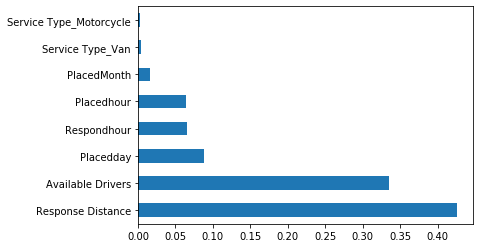

```python
feat_importances = pd.Series(rf.feature_importances_, index=X.columns)
feat_importances.nlargest(15).plot(kind='barh')
```

```python
feature_labels=np.array(['Available Drivers', 'Response Distance', 'Stage', 'Placedday', 'PlacedMonth', 'Placedhour', 'Respondhour', 'Service Type_Motorcycle', 'Service Type_Van'])
importance = rf.feature_importances_
feature_indexes_by_importance = importance.argsort()
for index in feature_indexes_by_importance:
    print('{}-{:.2f}%'.format(feature_labels[index], (importance[index] *100.0)))
```

[output not shown]

# Logistic Regression

```python
from sklearn.linear_model import LogisticRegression
from sklearn import metrics
X_train, X_test, y_train, y_test = train_test_split(X, y, test_size=0.3, random_state=0)
logreg = LogisticRegression()
logreg.fit(X_train, y_train)
```

```
LogisticRegression(C=1.0, class_weight=None, dual=False, fit_intercept=True,
                   intercept_scaling=1, l1_ratio=None, max_iter=100,
                   multi_class='warn', n_jobs=None, penalty='l2',
                   random_state=None, solver='warn', tol=0.0001, verbose=0,
                   warm_start=False)
```

```python
from sklearn.metrics import accuracy_score
print('Logistic regression accuracy: {:.3f}'.format(accuracy_score(y_test, logreg.predict(X_test))))
```

```
Logistic regression accuracy: 0.882
```

```python
logRegprediction = logreg.predict(X_test)
from sklearn.metrics import classification_report, accuracy_score
print(classification_report(y_test,logRegprediction ))
print(accuracy_score(y_test, logRegprediction ))
```

```
              precision    recall  f1-score   support

           0       0.50      0.04      0.07       559
           1       0.89      1.00      0.94      4176

    accuracy                           0.88      4735
   macro avg       0.69      0.52      0.50      4735
weighted avg       0.84      0.88      0.83      4735

0.8819429778247097
```

# Gradient Boosting Classifier

```python
from sklearn.model_selection import train_test_split
X_train, X_test, y_train, y_test = train_test_split(X, y, test_size=0.2, random_state=42)  # 80% training and 20% test
```

```python
from sklearn.ensemble import GradientBoostingClassifier
gb = GradientBoostingClassifier()
gb.fit(X_train, y_train)
y_pred = gb.predict(X_test)
```

```python
from sklearn import metrics
print("Accuracy:",metrics.accuracy_score(y_test, y_pred))
print("Precision:",metrics.precision_score(y_test, y_pred))
print("Recall:",metrics.recall_score(y_test, y_pred))
```

```
Accuracy: 0.8875514729173266
Precision: 0.8913809676385773
Recall: 0.9942816297355254
```

# XGBOOST

```python
import xgboost as xgb
from sklearn.model_selection import KFold, cross_val_score, train_test_split
```

```python
xgb_model = xgb.XGBClassifier(max_depth=5, learning_rate=0.08, objective= 'binary:logistic',n_jobs=-1).fit(X_train, y_train)
```

```python
print('Accuracy of XGB classifier on training set: {:.2f}'
       .format(xgb_model.score(X_train, y_train)))
print('Accuracy of XGB classifier on test set: {:.2f}'
       .format(xgb_model.score(X_test[X_train.columns], y_test)))
```

```
Accuracy of XGB classifier on training set: 0.89
Accuracy of XGB classifier on test set: 0.89
```

```python
y_pred = xgb_model.predict(X_test)
print(classification_report(y_test, y_pred))
```

```
              precision    recall  f1-score   support

           0       0.46      0.05      0.09       359
           1       0.89      0.99      0.94      2798

    accuracy                           0.89      3157
   macro avg       0.68      0.52      0.52      3157
weighted avg       0.84      0.89      0.84      3157
```